# Model diagnostics: Good classmates

# Model diagnostics

## Linear relationship

### Visualization

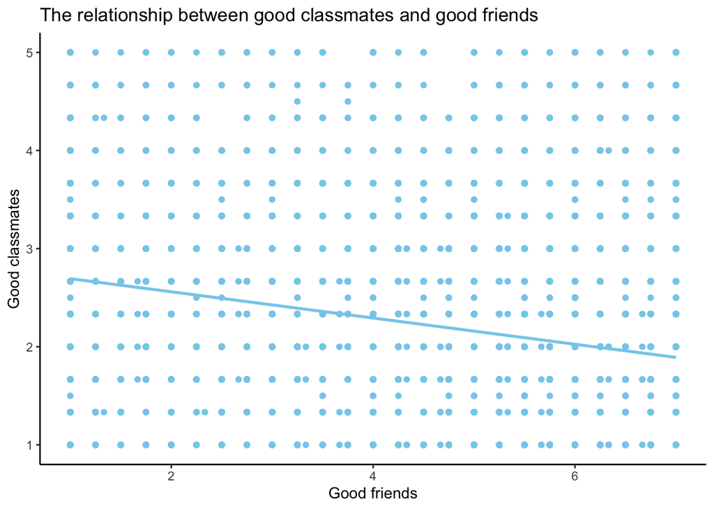

```r
ggplot(df_model, aes(good_freinds, good_classmates)) +
  geom_point(color = "skyblue") +
  geom_smooth(method = "lm", se = FALSE, color = "skyblue") +
  labs(title = "The relationship between good classmates and good friends",
       x = "Good friends",
       y = "Good classmates") +
  theme_classic()
```

Well, the relationship between these variables is not really linear.

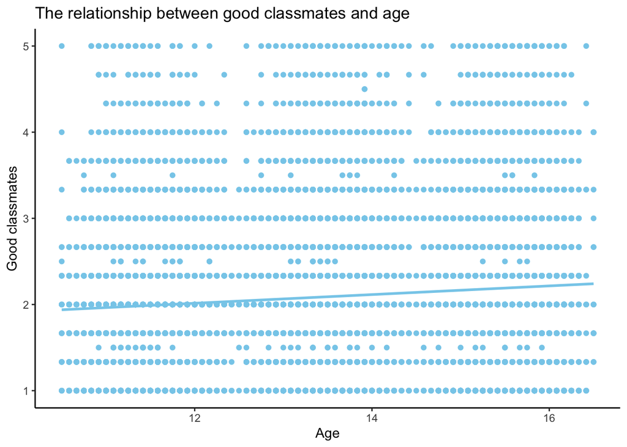

```r
ggplot(df_model, aes(AGE, good_classmates)) +
  geom_point(color = "skyblue") +
  geom_smooth(method = "lm", se = FALSE, color = "skyblue") +
  labs(title = "The relationship between good classmates and age",
       x = "Age",
       y = "Good classmates") +
  theme_classic()
```

The same situation with age and good classmates.

### Independent variable transformation

Let’s try Box-Tidwell test to check whether the relationship between continuous predictors and outcome variable is linear.

```r
library(car)
boxTidwell(good_classmates ~ AGE + good_freinds, data = df_model) # shows the power to be raised to
```

```
##              MLE of lambda Score Statistic (z)  Pr(>|z|)
## AGE                -5.5533             -4.9322 8.132e-07 ***
## good_freinds        3.0918            -17.5363 < 2.2e-16 ***
## ---
## Signif. codes:  0 '***' 0.001 '**' 0.01 '*' 0.05 '.' 0.1 ' ' 1
##
## iterations =  4
```

```r
# lambda close 0 - log
# lambda close 2 - quadratic term, others - do not transfrom
```

- Although significant p-value, age and good friends should not be transformed somehow as MLE of lambda is too high in both cases, so there is no sense to do smth.

### Dependent variable transformation

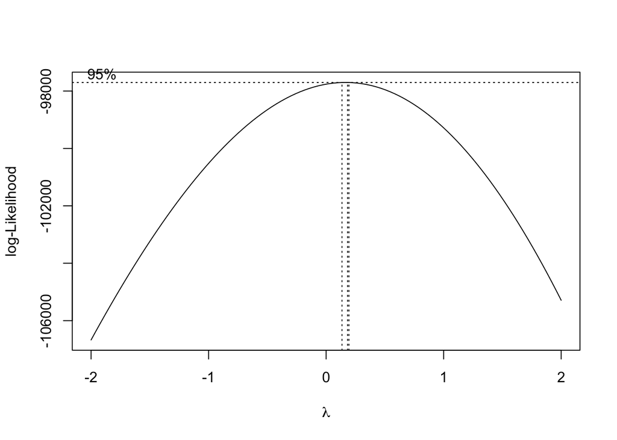

```r
library(MASS)
boxcox(model_1) # shows the power to be raised to
```

```r
# lambda close 0 - log
# lambda close 1 - no transformations
```

As I can see from the graph, lambda is close to 0, which means that dependent variable should be transformed to log-scale.

## Residual normality

### Q-Q plot

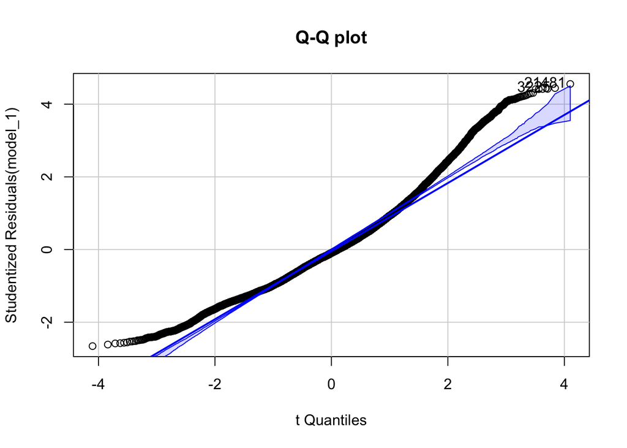

```
## [1]  3225 21481
```

```r
qqPlot(model_1, labels = row.names(good_classmates), main = "Q-Q plot")
```

- As we see from the plot, many observations do not follow blue line and are out of its confidence intervals, especially observations above 2 SD. So, model works poorly for observations above 2 SD.

### Density plot

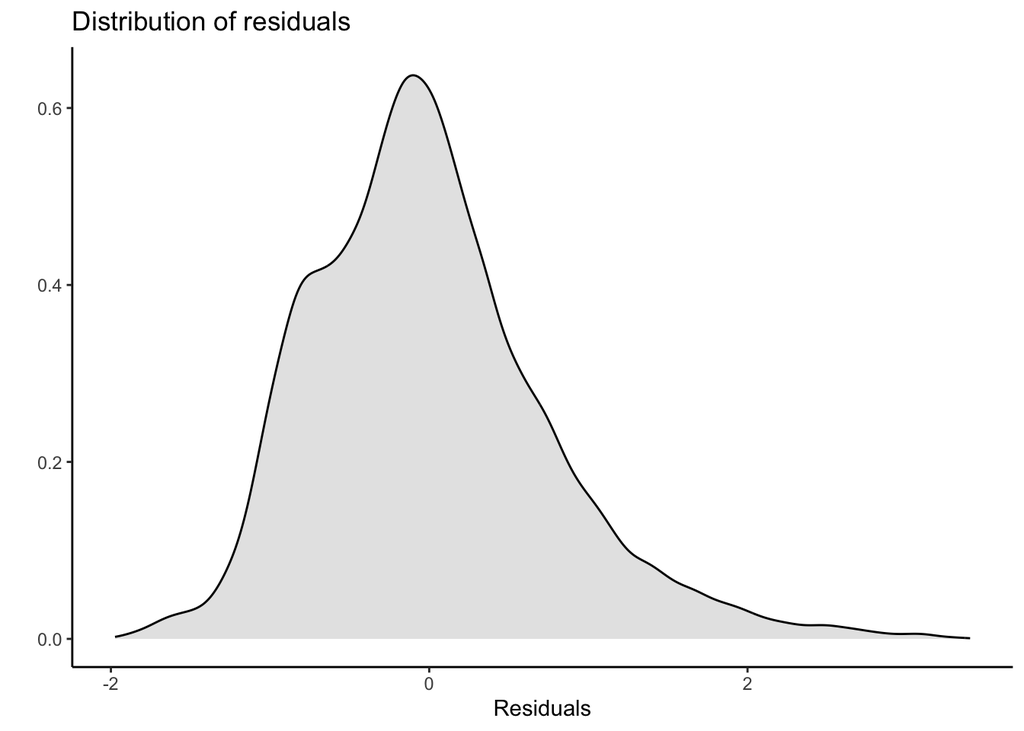

```r
ggplot(df_model, aes(residuals(model_1))) +
  geom_density(fill = "#e5e5e5") +
labs(x = "Residuals",
     y = " " ,
     title = "Distribution of residuals") +
   theme_classic()
```

The distribution of residuals is skewed to the right as there is this heavy right tail.

I can conclude that residuals are not normally distributed.